# Tugas Pertemuan 4

2026-09-11

# Proses MA(2)

Proses MA(2) dapat dituliskan sebagai berikut:

$$y_t = c + e_t + \theta_1 e_{t-1} + \theta_2 e_{t-2}$$

Akan dibangkitkan proses MA(2) dengan $\theta_1 = 0.4$ dan $\theta_2 = 0.6$ sebanyak 300 observasi dan $c = 0$.

## Pembangkitan Proses MA(2)

### Cara manual (loop)

Karena diperlukan dua nilai awal untuk $e_{t-1}$ dan $e_{t-2}$, gunakan dua nilai pertama *white noise* sebagai nilai awal.

```r
theta1 <- 0.4
theta2 <- 0.6

ma2 <- wn
ma2[1] <- wn[1]
ma2[2] <- wn[2] + theta1 * wn[1]
for (i in 3:n) {
  ma2[i] <- wn[i] + theta1 * wn[i - 1] + theta2 * wn[i - 2]
}
ma2
```

```
##   [1] -1.207065749 -0.205397058  0.471173424 -1.745463687  0.141510314
##   [6] -0.729712854 -0.114842790 -0.472894305 -1.127948717 -1.443797742
##  [11] -1.171879031 -1.723286222 -1.461924092 -0.845074607  0.519525249
##  [16]  0.312187420  0.020572732 -1.181770516 -1.508255550  1.534249256
##  [21]  0.598119283  1.012450498 -0.556369299 -0.011041246 -0.774213194
##  [26] -1.449939345 -0.420758391 -1.662676381 -0.079747157 -1.556197355
##  [31]  0.718835126 -0.596243221 -0.238298741 -1.070389923 -2.255260716
##  [36] -2.120011486 -3.624543435 -2.913580609 -2.138714925 -1.388210999
##  [41]  1.086560934 -0.768382742 -0.413123964 -1.263954490 -1.619808057
##  [46] -1.534624150 -2.091327966 -2.276021753 -1.689013389 -1.457572736
##  [51] -2.319068111 -1.602598402 -2.425338748 -1.807763414 -1.233628102
##  [56] -0.110845196  1.775654086  0.223607057  2.285258743 -0.979456751
##  [61]  1.157010823  2.116941328  1.378789117  0.845856907 -0.296314421
##  [66]  1.372262398 -0.432336811  1.978634754  1.193531021  1.688995021
##  [71]  0.939220832 -0.250827924 -0.544575725  0.228395751  2.109671129
```

[output cut: 45 more lines]

### Cara arima.sim()

```r
ma2.sim <- arima.sim(list(order = c(0, 0, 2), ma = c(theta1, theta2)), n = n)
ma2.sim
```

```
## Time Series:
## Start = 1
## End = 300
## Frequency = 1
##   [1] -0.908714261  0.366069559  0.319892749 -0.033692645 -0.749809541
##   [6]  1.023224875 -0.103827746  1.553027734  1.508813504  1.490258435
##  [11]  0.638775303  0.057508568 -0.761313741  1.006804154  0.046165301
##  [16]  2.226792228 -0.031351321  0.058227766 -0.452682262 -0.306828839
##  [21] -0.408896770 -1.768664231 -0.905163217 -1.653388217  0.814020129
##  [26] -0.949587092  1.394975120 -0.770061199  0.708742509  0.626264945
##  [31]  0.016220780  0.886163244 -0.177443664 -0.837739266 -0.776948985
##  [36]  0.830630275  0.271737011  0.068438994 -0.509614613 -0.182137038
##  [41]  1.054967504  1.724174690  1.131301118  1.891160132 -0.238116411
##  [46] -1.951472236 -1.868044756 -2.111236903 -2.805388403 -0.673455997
##  [51] -1.948408128 -0.202080988 -2.147789666 -0.222949385  1.157974906
```

[output cut: 49 more lines]

## Karakteristik MA(2)

### Plot Time Series

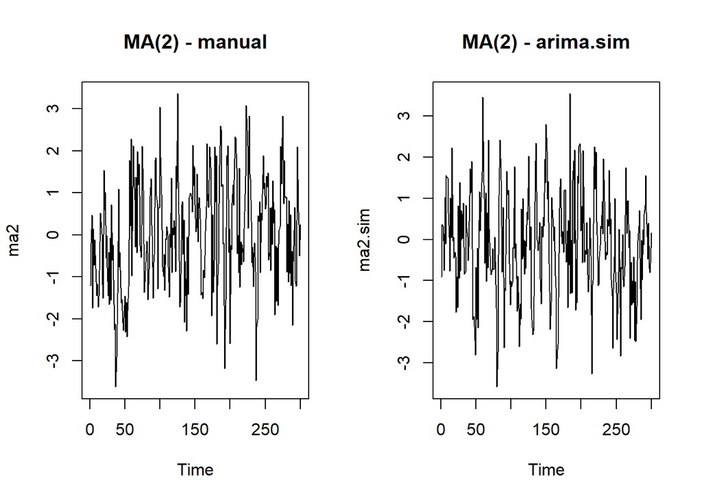

```r
par(mfrow = c(1, 2))
ts.plot(ma2, main = "MA(2) - manual")
ts.plot(ma2.sim, main = "MA(2) - arima.sim")
```

```r
par(mfrow = c(1, 1))
```

Berdasarkan plot time series tersebut, terlihat bahwa data MA(2) yang dibangkitkan berfluktuasi di sekitar rataan yang konstan, sehingga **stasioner dalam rataan**. Proses MA berorde berapa pun selalu stasioner karena hanya melibatkan kombinasi linear white noise yang jumlah lag-nya terbatas.

### Plot ACF

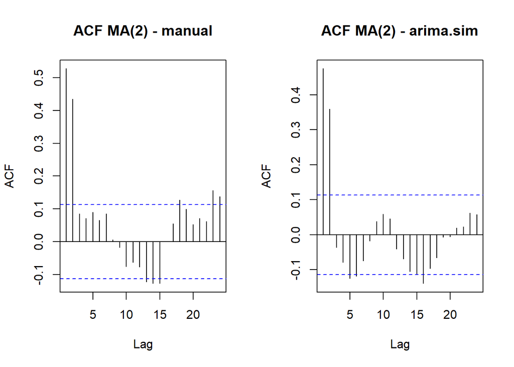

```r
par(mfrow = c(1, 2))
acf(ma2, main = "ACF MA(2) - manual")
acf(ma2.sim, main = "ACF MA(2) - arima.sim")
```

```r
par(mfrow = c(1, 1))
```

Berdasarkan plot ACF tersebut, terlihat bahwa plot ACF **cuts off** di lag ke-2, sesuai dengan teori bahwa ACF MA(q) terpotong tajam setelah lag q.

### Plot PACF

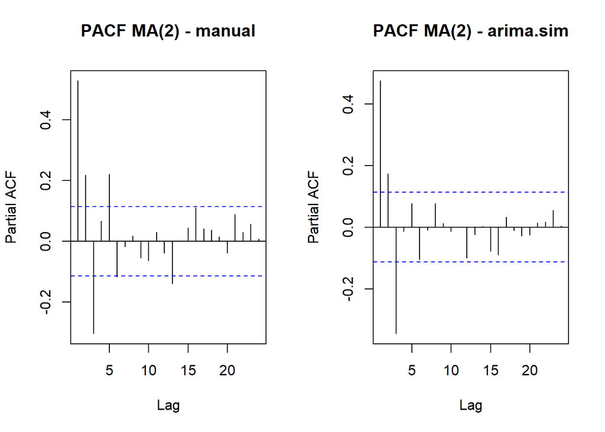

```r
par(mfrow = c(1, 2))
pacf(ma2, main = "PACF MA(2) - manual")
pacf(ma2.sim, main = "PACF MA(2) - arima.sim")
```

```r
par(mfrow = c(1, 1))
```

Berdasarkan plot PACF tersebut, terlihat bahwa plot PACF cenderung **tails off** (meluruh secara bertahap), sesuai dengan teori untuk proses MA.

### Plot EACF

```r
TSA::eacf(ma2)
```

```
## AR/MA
##   0 1 2 3 4 5 6 7 8 9 10 11 12 13
## 0 x x o o o o o o o o o  o  x  x
## 1 x x x o o o o o o o o  o  o  o
## 2 x x x x o o o o o o o  o  o  o
## 3 x x x x x o o o o o o  o  o  o
## 4 x x x x x o o o o o o  o  o  o
## 5 x x o x x o x o o o o  o  o  o
## 6 x x x o x o o x o o o  o  o  o
## 7 x o x o x o o x o o o  o  o  o
```

```r
TSA::eacf(ma2.sim)
```

```
## AR/MA
##   0 1 2 3 4 5 6 7 8 9 10 11 12 13
## 0 x x o o x x o o o o o  o  o  o
## 1 x x x o o o o o o o o  o  o  o
## 2 x x x o o o o o o o o  o  o  o
## 3 o x x x o o o o o o o  o  o  o
## 4 x o x x x o o o o o o  o  o  o
## 5 x x x x x x o o o o o  o  o  o
## 6 o x x x o o o o o o o  o  o  o
## 7 x x x x o o o o o o o  o  o  o
```

Berdasarkan pola segitiga nol pada plot EACF, terlihat bahwa segitiga nol berada pada ordo AR(0) dan ordo MA(2), sesuai dengan model yang dibangkitkan.

## Scatterplot Antar Lag

### Korelasi antara $Y_t$ dengan $Y_{t-1}$

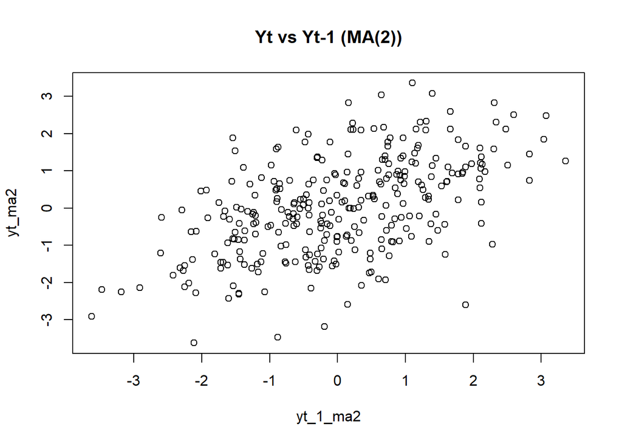

```r
yt_ma2 <- ma2[-1]
yt_1_ma2 <- ma2[-n]
plot(y = yt_ma2, x = yt_1_ma2, main = "Yt vs Yt-1 (MA(2))")
```

```r
cor(yt_ma2, yt_1_ma2)
```

```
## [1] 0.5282201
```

Korelasi teoritis:

$$\rho_1 = \frac{\theta_1(1+\theta_2)}{1+\theta_1^2+\theta_2^2} =
\frac{0.4(1+0.6)}{1+0.4^2+0.6^2} = 0.4211$$

### Korelasi antara $Y_t$ dengan $Y_{t-2}$

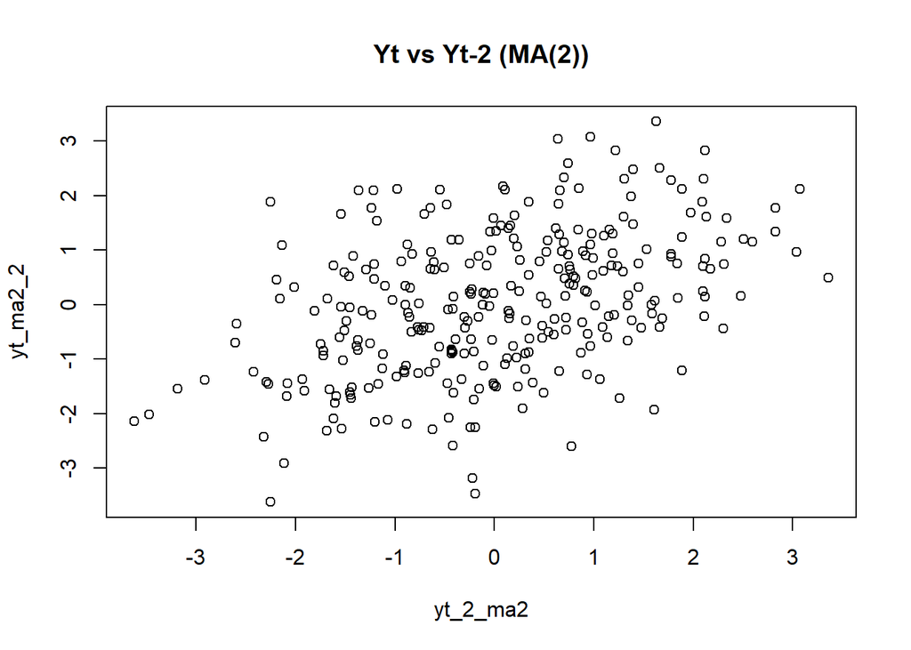

```r
yt_ma2_2 <- ma2[-c(1, 2)]
yt_2_ma2 <- ma2[-c(n - 1, n)]
plot(y = yt_ma2_2, x = yt_2_ma2, main = "Yt vs Yt-2 (MA(2))")
```

```r
cor(yt_ma2_2, yt_2_ma2)
```

```
## [1] 0.4356204
```

Korelasi teoritis:

$$\rho_2 = \frac{\theta_2}{1+\theta_1^2+\theta_2^2} = \frac{0.6}{1.52} =
0.3947$$

### Korelasi antara $Y_t$ dengan $Y_{t-3}$

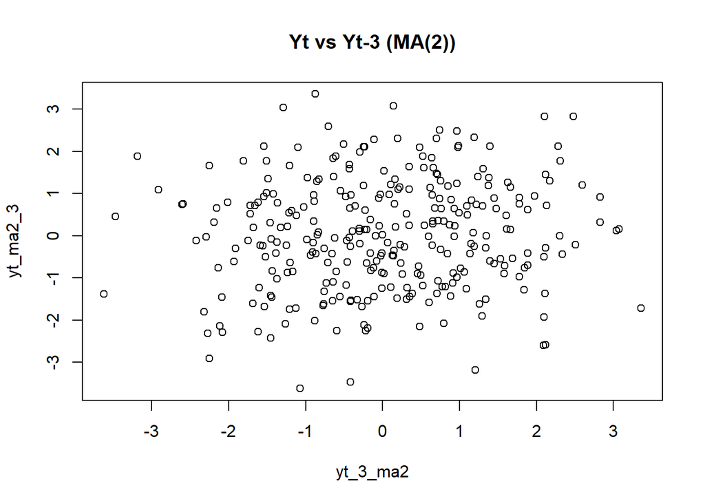

```r
yt_ma2_3 <- ma2[-c(1, 2, 3)]
yt_3_ma2 <- ma2[-c(n - 2, n - 1, n)]
plot(y = yt_ma2_3, x = yt_3_ma2, main = "Yt vs Yt-3 (MA(2))")
```

```r
cor(yt_ma2_3, yt_3_ma2)
```

```
## [1] 0.08544546
```

Karena orde MA hanya sampai lag 2, secara teoritis $\rho_3 = 0$. Hasil korelasi dari data bangkitan cenderung mendekati 0, sesuai dengan teori bahwa MA(q) tidak berkorelasi untuk lag $> q$.

### Rekap korelasi teoritis MA(2) dengan `ARMAacf()`

R juga menyediakan fungsi `ARMAacf()` untuk menghitung ACF teoritis suatu model ARMA secara otomatis, tanpa perlu menurunkan rumus secara manual.

```r
ARMAacf(ma = c(theta1, theta2), lag.max = 3)
```

```
##         0         1         2         3
## 1.0000000 0.4210526 0.3947368 0.0000000
```

# Proses AR(2)

Proses AR(2) dapat dituliskan sebagai berikut:

$$y_t = c + e_t + \phi_1 Y_{t-1} + \phi_2 Y_{t-2}$$

Akan dibangkitkan proses AR(2) dengan $\phi_1 = 0.5$ dan $\phi_2 = 0.2$ sebanyak 300 observasi dan $c = 0$.

## Pembangkitan Proses AR(2)

### Cara manual (loop)

```r
phi1 <- 0.5
phi2 <- 0.2

ar2 <- wn
ar2[1] <- wn[1]
ar2[2] <- wn[2] + phi1 * ar2[1]
for (i in 3:n) {
  ar2[i] <- wn[i] + phi1 * ar2[i - 1] + phi2 * ar2[i - 2]
}
ar2
```

```
##   [1] -1.207065749 -0.326103633  0.679976211 -2.070930324 -0.470345231
##   [6] -0.143302788 -0.740460400 -0.945522614 -1.185305386 -1.671795045
##  [11] -1.550151299 -2.107821103 -2.140194706 -1.427202757 -0.182146261
##  [16] -0.486799176 -0.790838346 -1.403974425 -1.697326562  1.286377013
##  [21]  0.437811414 -0.014504787 -0.360237983  0.276569492 -0.627483098
##  [26] -1.706632561 -0.404057179 -1.567010825 -0.879455148 -1.689078340
##  [31]  0.081867346 -0.772475074 -1.079304105 -1.195405128 -2.442656854
##  [36] -2.628028715 -3.982585377 -3.857891624 -3.019756746 -2.747354238
##  [41] -0.528132203 -1.882179673 -1.902080911 -1.608099392 -2.178805954
##  [46] -2.379537173 -2.732847970 -3.094317305 -2.617556366 -2.424491601
##  [51] -3.541788331 -2.837868410 -3.236181496 -3.200626439 -2.409859042
##  [56] -1.281998990  0.524846169 -0.767330137  1.327213794 -0.647667678
##  [61]  0.598197384  2.718556227  1.444157201  0.596156266  0.579304817
##  [66]  2.185968110  0.070237282  1.840139442  2.263681968  1.836341670
##  [71]  1.377800067  0.600699629  0.209385895  0.873119441  2.548707761
```

[output cut: 45 more lines]

### Cara arima.sim()

```r
ar2.sim <- arima.sim(list(order = c(2, 0, 0), ar = c(phi1, phi2)), n = n)
ar2.sim
```

```
## Time Series:
## Start = 1
## End = 300
## Frequency = 1
##   [1]  0.069137269  1.059226921  0.084320021  1.714271141  1.917245752
##   [6] -0.357563866  0.628624993 -1.176363203 -1.927149059 -1.128426198
##  [11] -0.892944689 -0.704865761  0.733259406  0.520644436 -0.266112721
##  [16]  0.090660818 -0.522288644 -0.311123732 -1.408031507 -0.881484980
##  [21] -0.619412400 -1.187746683 -0.676525197 -1.224580286 -1.391603042
##  [26] -1.145156403 -0.360057892 -0.614397214 -0.188518862  0.752885319
##  [31]  0.053477809  0.073696700  0.558798453 -0.964023883  0.173573718
##  [36] -0.640981504 -1.423822035 -2.608111089 -2.303798155 -2.843723560
##  [41] -3.061069559 -0.471988154 -2.060354654 -0.127065040  0.069642190
##  [46] -0.875381028 -1.034992774 -1.102772105 -0.567975238 -0.852866969
##  [51]  0.286818998 -0.319850797 -2.267907809 -1.294140840 -2.952608828
```

[output cut: 49 more lines]

## Karakteristik AR(2)

### Plot Time Series

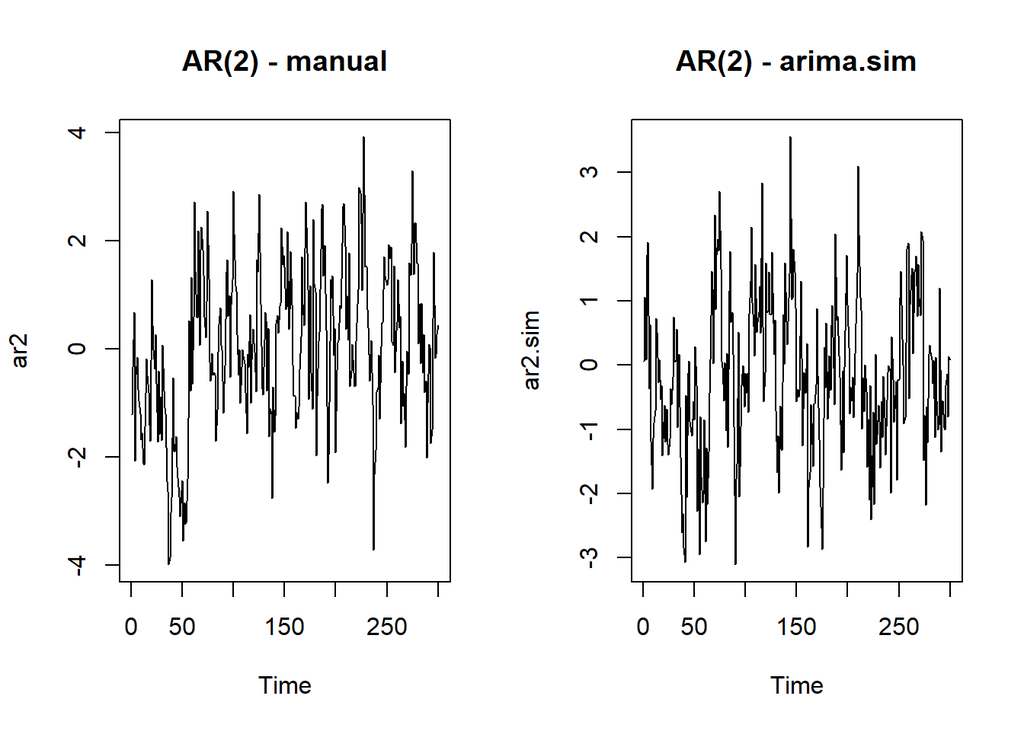

```r
par(mfrow = c(1, 2))
ts.plot(ar2, main = "AR(2) - manual")
ts.plot(ar2.sim, main = "AR(2) - arima.sim")
```

```r
par(mfrow = c(1, 1))
```

Berdasarkan plot time series tersebut, terlihat bahwa data cenderung **stasioner dalam rataan** (berfluktuasi di sekitar nilai tengah yang konstan). Hal ini dapat diperkuat dengan mengecek akar-akar polinomial karakteristik AR:

```r
polyroot(c(1, -phi1, -phi2))
```

```
## [1]  1.311738+0i -3.811738+0i
```

```r
Mod(polyroot(c(1, -phi1, -phi2)))
```

```
## [1] 1.311738 3.811738
```

Karena seluruh akar memiliki modulus $> 1$ (berada di luar lingkaran satuan), proses AR(2) ini **stasioner**.

### Plot ACF

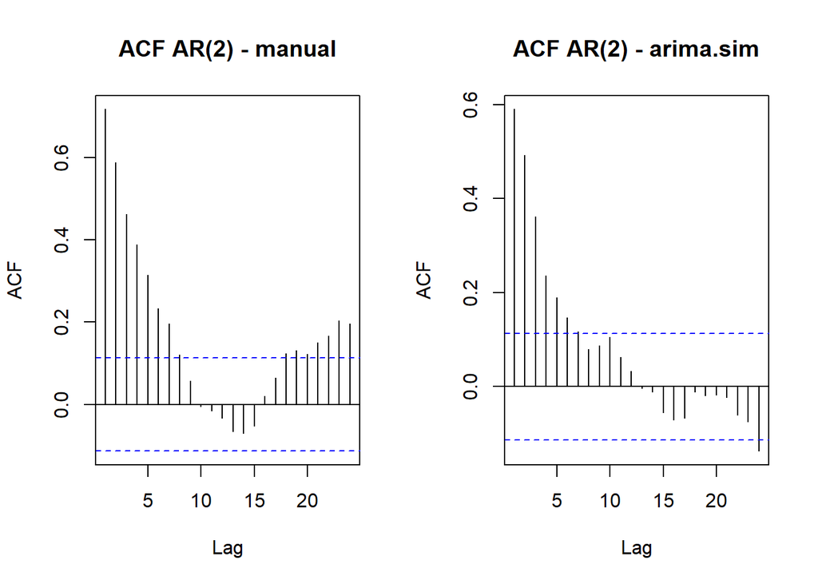

```r
par(mfrow = c(1, 2))
acf(ar2, main = "ACF AR(2) - manual")
acf(ar2.sim, main = "ACF AR(2) - arima.sim")
```

```r
par(mfrow = c(1, 1))
```

Berdasarkan plot ACF tersebut, terlihat bahwa plot ACF **tails off** dan cenderung membentuk pola grafik sinus/eksponensial menurun, sesuai dengan teori proses AR.

### Plot PACF

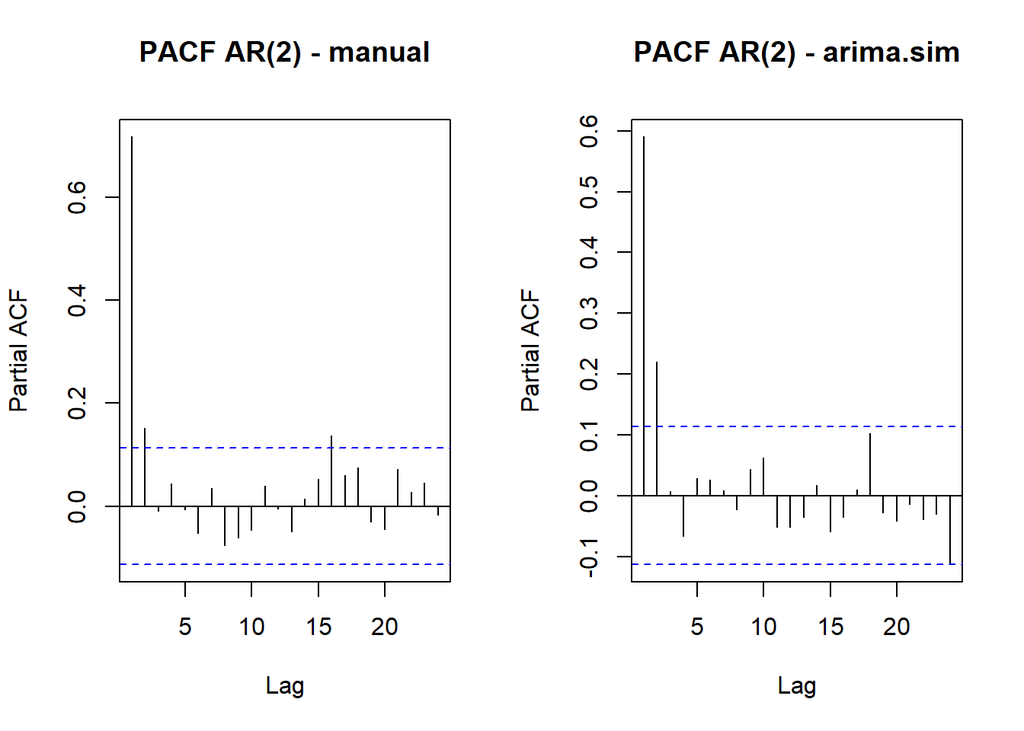

```r
par(mfrow = c(1, 2))
pacf(ar2, main = "PACF AR(2) - manual")
pacf(ar2.sim, main = "PACF AR(2) - arima.sim")
```

```r
par(mfrow = c(1, 1))
```

Berdasarkan plot PACF tersebut, terlihat bahwa plot PACF **cuts off** setelah lag ke-2, sejalan dengan teori bahwa PACF AR(p) terpotong tajam setelah lag p.

### Plot EACF

```r
TSA::eacf(ar2)
```

```
## AR/MA
##   0 1 2 3 4 5 6 7 8 9 10 11 12 13
## 0 x x x x x x x x o o o  o  o  o
## 1 x o o o o o o o o o o  o  o  o
## 2 o o o o o o o o o o o  o  o  o
## 3 x x o o o o o o o o o  o  o  o
## 4 x x o o o o o o o o o  o  o  o
## 5 o x o x o o x o o o o  o  o  o
## 6 x x x x o o o o o o o  o  o  o
## 7 x x x o x x o o o o o  o  o  o
```

```r
TSA::eacf(ar2.sim)
```

```
## AR/MA
##   0 1 2 3 4 5 6 7 8 9 10 11 12 13
## 0 x x x x x x o o o o o  o  o  o
## 1 x o o o o o o o o o o  o  o  o
## 2 o x o o o o o o o o o  o  o  o
## 3 o x o o o o o o o o o  o  o  o
## 4 x x x o o o o o o o o  o  o  o
## 5 x x x x o o o o o o o  o  o  o
## 6 x x o x o o o o o o o  o  o  o
## 7 x x x x o o o o o o o  o  o  o
```

Berdasarkan pola segitiga nol pada plot EACF, terlihat bahwa segitiga nol berada pada ordo AR(2) dan ordo MA(0), sesuai dengan model yang dibangkitkan.

## Scatterplot Antar Lag

### Korelasi antara $Y_t$ dengan $Y_{t-1}$

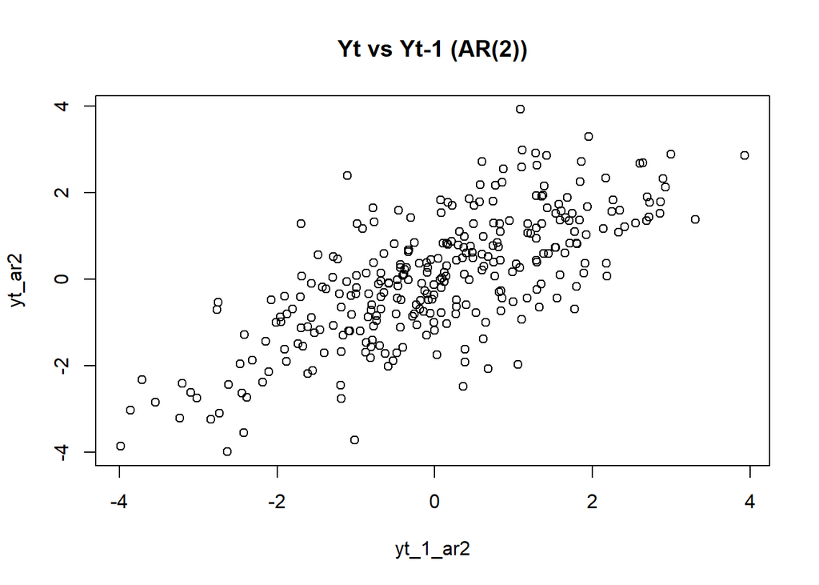

```r
yt_ar2 <- ar2[-1]
yt_1_ar2 <- ar2[-n]
plot(y = yt_ar2, x = yt_1_ar2, main = "Yt vs Yt-1 (AR(2))")
```

```r
cor(yt_ar2, yt_1_ar2)
```

```
## [1] 0.7181941
```

Korelasi teoritis (persamaan Yule-Walker):

$$\rho_1 = \frac{\phi_1}{1-\phi_2} = \frac{0.5}{0.8} = 0.625$$

### Korelasi antara $Y_t$ dengan $Y_{t-2}$

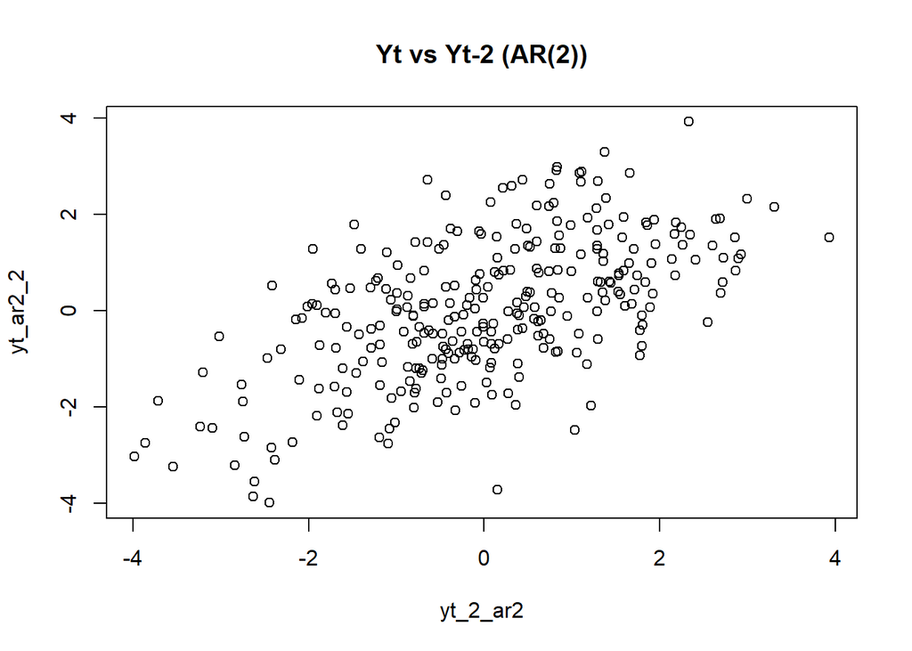

```r
yt_ar2_2 <- ar2[-c(1, 2)]
yt_2_ar2 <- ar2[-c(n - 1, n)]
plot(y = yt_ar2_2, x = yt_2_ar2, main = "Yt vs Yt-2 (AR(2))")
```

```r
cor(yt_ar2_2, yt_2_ar2)
```

```
## [1] 0.5889847
```

Korelasi teoritis:

$$\rho_2 = \phi_1\rho_1+\phi_2\rho_0 = 0.5(0.625)+0.2(1) = 0.5125$$

### Korelasi antara $Y_t$ dengan $Y_{t-3}$

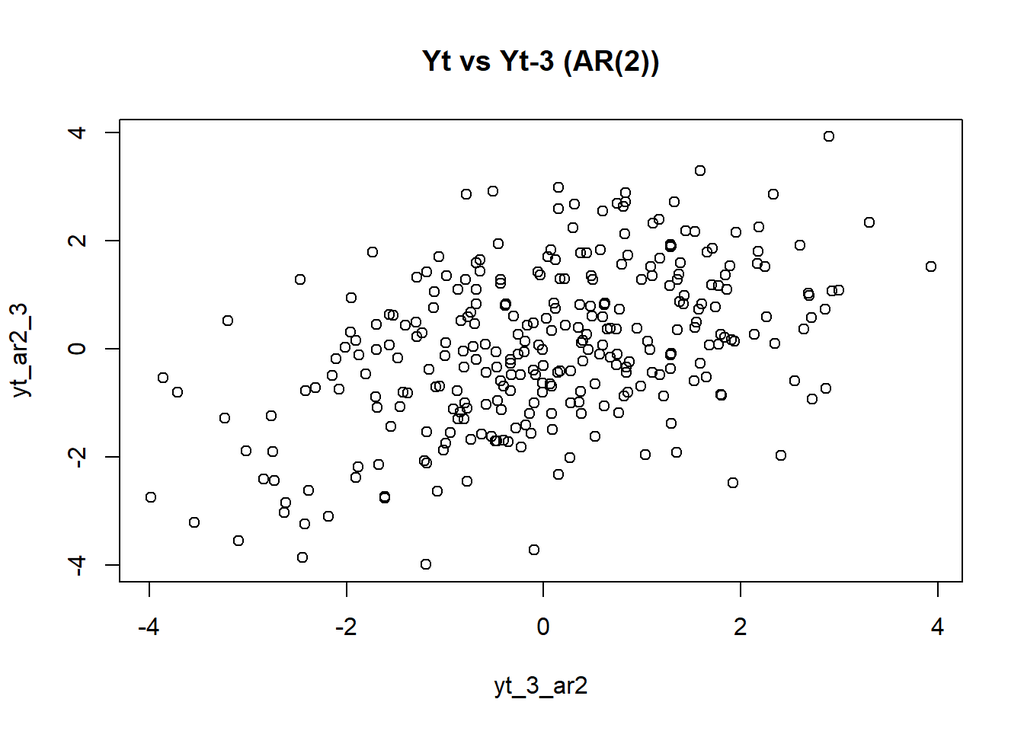

```r
yt_ar2_3 <- ar2[-c(1, 2, 3)]
yt_3_ar2 <- ar2[-c(n - 2, n - 1, n)]
plot(y = yt_ar2_3, x = yt_3_ar2, main = "Yt vs Yt-3 (AR(2))")
```

```r
cor(yt_ar2_3, yt_3_ar2)
```

```
## [1] 0.4630342
```

Korelasi teoritis:

$$\rho_3 = \phi_1\rho_2+\phi_2\rho_1 = 0.5(0.5125)+0.2(0.625) = 0.3813$$

Berbeda dengan MA(2), korelasi AR(2) tidak langsung nol setelah lag tertentu, melainkan meluruh secara bertahap (tails off) mengikuti rekursi Yule-Walker di atas.

### Rekap korelasi teoritis AR(2) dengan `ARMAacf()`

```r
ARMAacf(ar = c(phi1, phi2), lag.max = 3)
```

```
##       0       1       2       3
## 1.00000 0.62500 0.51250 0.38125
```

# Proses ARMA(2,2)

Proses ARMA(2,2) dapat dituliskan sebagai berikut:

$$y_t = c + \phi_1 Y_{t-1} + \phi_2 Y_{t-2} + e_t + \theta_1 e_{t-1} +
\theta_2 e_{t-2}$$

Akan dibangkitkan proses ARMA(2,2) dengan $\phi_1 = 0.5$, $\phi_2 = 0.2$, $\theta_1 = 0.4$, dan $\theta_2 = 0.6$ sebanyak 300 observasi dan $c = 0$.

## Pembangkitan Proses ARMA(2,2)

### Cara manual (loop)

```r
arma22 <- wn
arma22[1] <- wn[1]
arma22[2] <- wn[2] + phi1 * arma22[1] + theta1 * wn[1]
for (i in 3:n) {
  arma22[i] <- phi1 * arma22[i - 1] + phi2 * arma22[i - 2] +
    wn[i] + theta1 * wn[i - 1] + theta2 * wn[i - 2]
}
arma22
```

```
##   [1] -1.20706575 -0.80892993 -0.17470469 -1.99460202 -0.89073163 -1.57399907
##   [7] -1.07998865 -1.32768845 -2.00779067 -2.71323077 -2.93005255 -3.73095865
##  [13] -3.91341393 -3.54797330 -2.03714419 -1.41597933 -1.09484577 -2.01238927
##  [19] -2.73341934 -0.23493827 -0.06603372  0.93244599 -0.10335305  0.12377143
##  [25] -0.73299809 -1.79168410 -1.46320006 -2.75261323 -1.74869379 -2.98106689
##  [31] -1.12143708 -1.75317514 -1.33917373 -2.09061181 -3.56840137 -4.32233453
##  [37] -6.49939098 -7.02774300 -6.95246462 -6.26999191 -3.43892795 -3.74184510
##  [43] -2.97183210 -3.49823956 -3.96329426 -4.21591919 -4.99194641 -5.61517880
##  [49] -5.49499207 -5.32810453 -6.08211879 -5.70927870 -6.49640186 -6.19782008
##  [55] -5.63181852 -4.16631847 -1.43386885 -1.32659106  1.33518944 -0.57718024
##  [61]  1.13545859  2.56923457  2.89049812  2.80495288  1.68426164  2.77538380
##  [67]  1.29220742  3.17981522  3.04188011  3.84589812  3.47054592  2.25362466
##  [73]  1.27634579  1.31729358  3.02358707  2.83893413  1.81428668  0.10302896
##  [79] -0.45121970 -0.85290753 -0.66635425 -0.93510416 -2.14779642 -2.08562341
##  [85] -1.51503473 -0.24121274  0.91556687  0.64537308  0.48311177 -1.14217407
```

[output cut: 35 more lines]

### Cara arima.sim()

```r
arma22.sim <- arima.sim(
  list(order = c(2, 0, 2), ar = c(phi1, phi2), ma = c(theta1, theta2)),
  n = n
)
arma22.sim
```

```
## Time Series:
## Start = 1
## End = 300
## Frequency = 1
##   [1] -2.16055656 -0.45018472 -1.39327611 -1.03395069 -1.13310653 -0.85191297
##   [7]  1.17212092 -0.93924298  0.72818720 -0.68463136  1.20847833  0.75544112
##  [13] -1.59243313 -1.38000929 -2.70260074 -2.45182575 -2.94967161 -2.76573816
##  [19]  0.10764412  0.70307151  0.93987571  2.23518822  1.04067584  1.10440783
##  [25] -1.08189454 -1.99060305 -0.29437563  0.73103442  2.56689379  2.41482665
##  [31]  2.50447906  2.52570508  2.38518100  2.29269057  2.76873910  2.15161756
##  [37]  2.39051525  0.73059865  2.22138578  2.74467588  1.51184238  1.19928857
##  [43]  0.27798601  0.95173757  1.81532284  1.24633215  0.05914326 -0.16922338
##  [49] -2.21454162 -0.94052281 -0.87955680 -1.87136268 -0.51325333 -1.62335245
##  [55] -1.11458764 -0.84039884  0.41152507  2.38253221  1.46744740  1.23139484
##  [61]  0.16016278  0.18831505 -0.20460942 -2.54515705 -2.79574934 -4.60533009
```

[output cut: 39 more lines]

### Cara fungsi arma.sim() (fungsi umum pembangkit ARMA)

Fungsi umum dari materi Pertemuan 4 juga dapat digunakan untuk membangkitkan model ini:

```r
arma.sim <- function(n, macoef, arcoef) {
  manum <- length(macoef)
  arnum <- length(arcoef)
  stopifnot(manum < n & arnum < n)
  wn <- rnorm(n, sd = 0.5)
  init <- max(manum, arnum)
  arma <- wn[1:init]
  for (i in (init + 1):n) {
    mastart <- i - manum
    maend <- i - 1
    arstart <- i - arnum
    arend <- i - 1
    arma[i] <- sum(arcoef * arma[arstart:arend]) +
      sum(macoef * wn[mastart:maend]) + wn[i]
  }
  return(arma)
}

arma22.fun <- arma.sim(n, macoef = c(theta1, theta2), arcoef = c(phi1, phi2))
arma22.fun
```

```
##   [1]  0.4231524456 -0.3842245120  0.1741887941  0.0367592189 -0.3155103425
##   [6] -0.1895211017 -0.6732927579  0.3523894334  0.3961633655 -0.1099079871
##  [11]  0.2591819173  0.0365115060  0.1054101133 -0.2633042814 -0.8549675237
##  [16] -0.5623069952 -1.4977761077 -1.0651576788 -1.1041152465 -0.6032100808
##  [21] -0.1270628481 -0.0273148887  1.2724767462  0.5138991697  1.7125261598
##  [26]  0.0820639438  0.1575010200 -1.0242362706 -1.3725243805 -0.6808819066
##  [31] -0.1644012302  0.9193618149  0.4153316407  0.6771226495  0.8062389355
##  [36]  1.3827456719  1.5015974236  1.4509130808  0.6183663338  0.6863504467
##  [41]  0.2172775632  0.0677575448  0.6782127880  0.1607617261  0.5975072655
##  [46]  0.3904823637  1.1058134913  1.0186096581  2.0636586060  1.8100303980
##  [51]  1.6777793857  1.2343101431  1.3533737713  0.0138165026  0.1083413672
##  [56] -0.4174315981 -0.1552711707 -0.2773608854 -1.1613205564 -0.7850946124
##  [61] -1.0306549159 -0.7747364799 -2.2496067969 -2.0007072847 -2.1620881520
##  [66] -1.5151316426 -1.6861256417 -1.1308096879 -1.5497154238 -0.7345252070
##  [71] -0.4812101579  0.4028429929  0.6917961534  0.5948796856  0.5065316908
```

[output cut: 45 more lines]

## Karakteristik ARMA(2,2)

### Plot Time Series

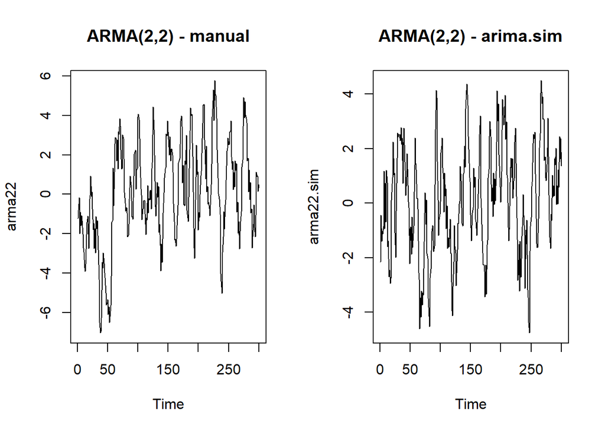

```r
par(mfrow = c(1, 2))
ts.plot(arma22, main = "ARMA(2,2) - manual")
ts.plot(arma22.sim, main = "ARMA(2,2) - arima.sim")
```

```r
par(mfrow = c(1, 1))
```

Karena bagian AR(2)-nya menggunakan koefisien $\phi_1 = 0.5$ dan $\phi_2 = 0.2$ yang sama dengan bagian AR(2) sebelumnya (akar polinomial karakteristik berada di luar lingkaran satuan), model ARMA(2,2) ini juga **stasioner dalam rataan**, terlihat dari plot time series yang berfluktuasi di sekitar rataan konstan.

### Plot ACF

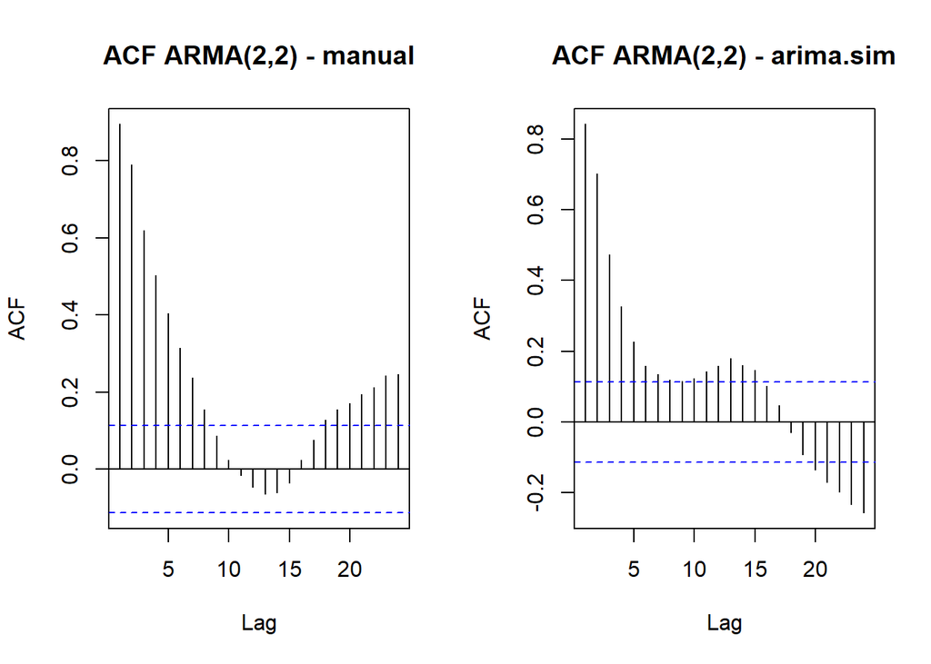

```r
par(mfrow = c(1, 2))
acf(arma22, main = "ACF ARMA(2,2) - manual")
acf(arma22.sim, main = "ACF ARMA(2,2) - arima.sim")
```

```r
par(mfrow = c(1, 1))
```

Berdasarkan plot ACF tersebut, terlihat bahwa model ARMA(2,2) hasil simulasi memiliki plot ACF yang **tails off**, sesuai dengan teori yang ada.

### Plot PACF

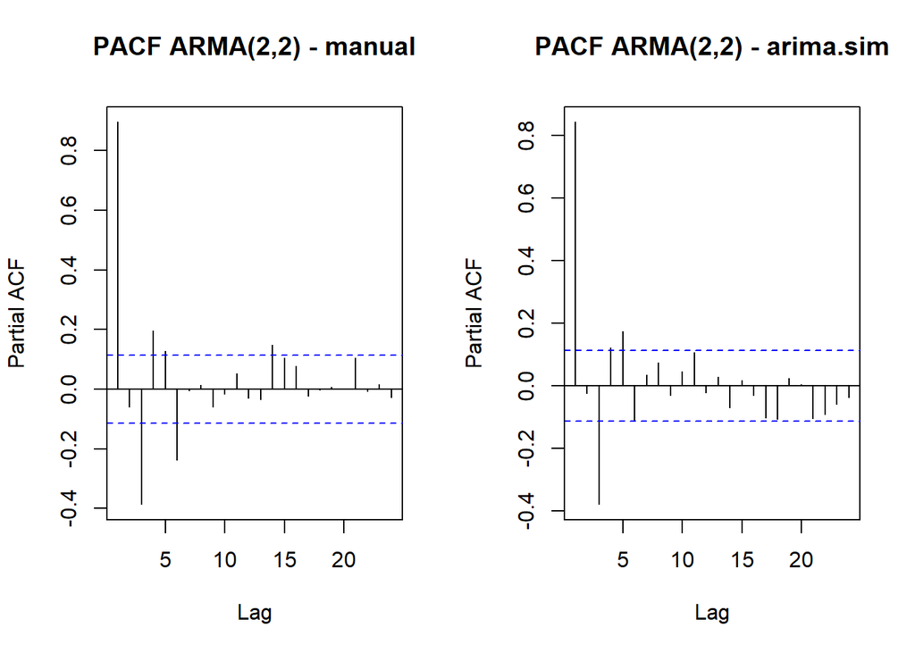

```r
par(mfrow = c(1, 2))
pacf(arma22, main = "PACF ARMA(2,2) - manual")
pacf(arma22.sim, main = "PACF ARMA(2,2) - arima.sim")
```

```r
par(mfrow = c(1, 1))
```

Berdasarkan plot PACF tersebut, terlihat bahwa model ARMA(2,2) hasil simulasi memiliki plot PACF yang **tails off**, sesuai dengan teori bahwa proses ARMA memiliki ACF maupun PACF yang sama-sama meluruh bertahap.

### Plot EACF

```r
TSA::eacf(arma22)
```

```
## AR/MA
##   0 1 2 3 4 5 6 7 8 9 10 11 12 13
## 0 x x x x x x x x o o o  o  o  o
## 1 o x o o o o x o o o o  o  o  o
## 2 x x o o o o x o o o o  o  o  o
## 3 x x o x o o x o o o o  o  o  o
## 4 x x x x o o x o o o o  o  o  o
## 5 x x x x x x x o o o o  o  o  o
## 6 o o x o x x o o o o o  o  o  o
## 7 o o x o x x o x o o o  o  o  o
```

```r
TSA::eacf(arma22.sim)
```

```
## AR/MA
##   0 1 2 3 4 5 6 7 8 9 10 11 12 13
## 0 x x x x x x x x o x x  x  x  x
## 1 o x o o o o o o o o o  o  x  o
## 2 o x o o o o o o o o o  o  x  o
## 3 x x o o o o o o o o o  o  o  o
## 4 x x o o x o o o o o o  o  o  o
## 5 x x x o o o o o o o o  o  o  o
## 6 x x x o x o o o o o o  o  o  o
## 7 x x x o x o o o o o o  o  o  o
```

Berdasarkan pola segitiga nol pada plot EACF, terlihat bahwa segitiga nol berada pada ordo AR(2) dan ordo MA(2), sesuai dengan model yang dibangkitkan.

## Scatterplot Antar Lag

### Korelasi antara $Y_t$ dengan $Y_{t-1}$

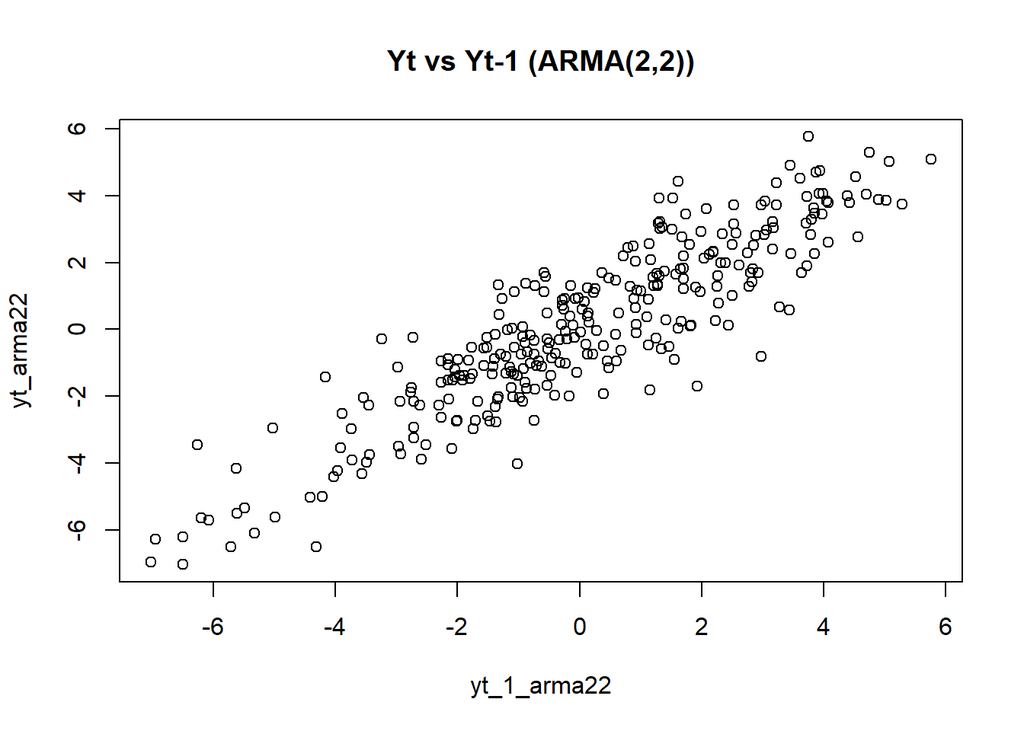

```r
yt_arma22 <- arma22[-1]
yt_1_arma22 <- arma22[-n]
plot(y = yt_arma22, x = yt_1_arma22, main = "Yt vs Yt-1 (ARMA(2,2))")
```

```r
cor(yt_arma22, yt_1_arma22)
```

```
## [1] 0.8955216
```

### Korelasi antara $Y_t$ dengan $Y_{t-2}$

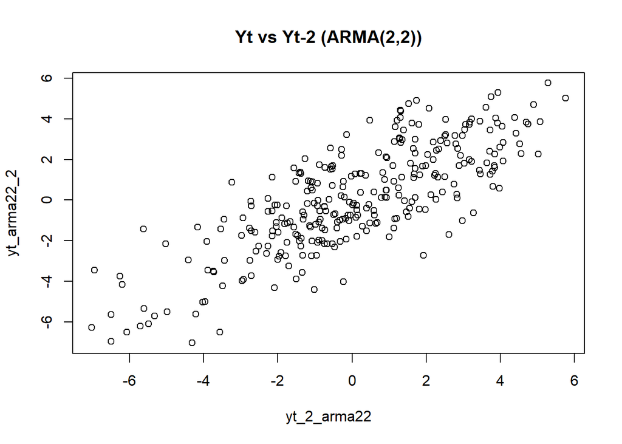

```r
yt_arma22_2 <- arma22[-c(1, 2)]
yt_2_arma22 <- arma22[-c(n - 1, n)]
plot(y = yt_arma22_2, x = yt_2_arma22, main = "Yt vs Yt-2 (ARMA(2,2))")
```

```r
cor(yt_arma22_2, yt_2_arma22)
```

```
## [1] 0.7899614
```

### Korelasi antara $Y_t$ dengan $Y_{t-3}$

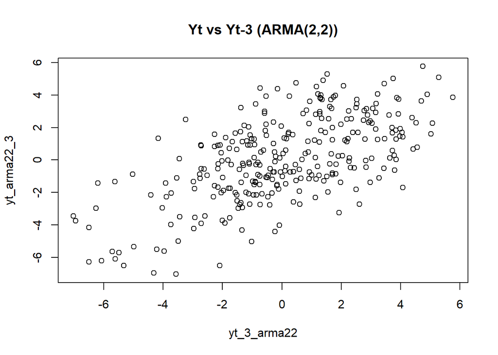

```r
yt_arma22_3 <- arma22[-c(1, 2, 3)]
yt_3_arma22 <- arma22[-c(n - 2, n - 1, n)]
plot(y = yt_arma22_3, x = yt_3_arma22, main = "Yt vs Yt-3 (ARMA(2,2))")
```

```r
cor(yt_arma22_3, yt_3_arma22)
```

```
## [1] 0.6195458
```

Untuk model campuran seperti ARMA(2,2), rumus korelasi teoritis manual cukup rumit karena harus menggabungkan komponen AR dan MA sekaligus. Cara paling praktis adalah memakai fungsi `ARMAacf()` yang menghitung ACF teoritis untuk model ARMA apa pun secara otomatis:

```r
ARMAacf(ar = c(phi1, phi2), ma = c(theta1, theta2), lag.max = 3)
```

```
##         0         1         2         3
## 1.0000000 0.8591993 0.7491908 0.5464353
```

Hasil korelasi dari data bangkitan (baik manual maupun `arima.sim`) terlihat mendekati nilai teoritis di atas, dan pola korelasinya meluruh bertahap (tails off) khas proses ARMA — tidak terputus tajam seperti MA murni, dan tidak mengikuti rekursi AR murni karena masih ada pengaruh komponen MA di lag-lag awal.

# Kesimpulan

| Proses | ACF | PACF | EACF (segitiga nol) | Stasioner |
| --- | --- | --- | --- | --- |
| MA(2): $\theta_1=0.4,\ \theta_2=0.6$ | cuts off di lag 2 | tails off | AR(0), MA(2) | Ya |
| AR(2): $\phi_1=0.5,\ \phi_2=0.2$ | tails off | cuts off di lag 2 | AR(2), MA(0) | Ya |
| ARMA(2,2) | tails off | tails off | AR(2), MA(2) | Ya |

Pola ACF dan PACF hasil simulasi konsisten dengan teori: MA(q) memotong ACF di lag q, AR(p) memotong PACF di lag p, dan ARMA(p,q) membuat keduanya meluruh bertahap.